# Advanced Topic - Landscape Metrics and Raster Data

Allison Vincent

5/8/2020

## Introducing the problem

My thesis research involves using a remote sensing data fusion model to monitor snow covered area in a mountain watershed. The questions we are trying to answer include:

1. Can we constrain the spatiotemporal distribution of snow cover in mountain watersheds over a large area and long period of time to better understand water delivery to the Critical Zone (or shallow subsurface)?
2. Can we create a high spatiotemporal resolution dataset to monitor snow covered area in a mountain watershed over a ~20 year period?

To do this, we are using the Spatial and Temporal Adaptive Reflectance Fusion Model (STARFM) (Gao et al., 2006) to downscale MODIS (low spatial, high temporal resoultion) data to fill in the gaps of Landsat (high spatial, low temporal resolution) data to monitor historical snow-covered area in detail on a daily basis. Landsat data with its 30 meter spatial resolution is useful for detailed monitoring of landscape features. Because it is only available every 7-16 days (depending on location), however, rapidly changing conditions, such as spring snowcover, can be missed. On the other hand, MODIS data is captured on a daily basis, but is too coarse at 250-500 meter spatial resolution to be used to discerne landscape changes at the scale necessary. Downscaling MODIS data is one way to resolve this issue. By using MODIS data to “fll-in” the gaps between days of Landsat acquisition, a dataset can be produced that contains synthetic imagery at a Landsat-like spatial resolution on a daily basis. This is important because snowcover is a landscape characteristic that can change rapidly from day-to-day, especially during times such as the spring snowmelt season.

Before being used as model input, MODIS and Landsat images are first processed by applying a cloud mask to remove any pixels that are classified as cloud or cloud shadow. The normalized difference snow index (NDSI) is then calculated for the remaining pixels covering the area of interest. Once an NDSI value for each pixel is obtained, both images are converted to the same projection and the MODIS imagery is rescaled to 30x30 meter pixels. These steps are all currently being done with Google Earth Engine, as it is easy to preprocess data on a cloud platform without having to pull multiple massive files onto a local machine.

To validate the results of the model, a single Landsat image is excluded from the model input data, and then layer is used to compare the synthetic image produced from the model from that same date to see how accurate the model’s prediction was. One way in which we quantify the performance of the model is by binary classification. We use the common NDSI threshold of 0.4 (Hall et al., 1995) to decide whether a pixel is classified as snow or no snow. Any value at 0.4 or above is given the label of “snow” (the positive classification), and any value below is given the label of “no snow” (the negative classification).

Once each pixel is placed into one of these categories, a confusion matrix of true positives, true negatives, false positives, and false negatives is generated. From these values we then calculate the following metrics to answer the questions:

accuracy - What fraction of pixels (snow and no-snow) does the model classify correctly? precision - What fraction of classified “snow” was actually snow? recall - What fraction of actual snow (the positive class) did the model catch? How good is the model at predicting snow? F-score - What is the accuracy of the model regarding its performance on identifying the positive (snow) class?

These last 3 metrics are used because, as our dates of analysis move further into the spring, snow becomes more scarce in the landscape and the negative, “no-snow”, class becomes the majority classifier, which can inflate the accuracy values for even an unskilled model.

In addition to the calculation of the F-score for the model output, it is also important to quantify how well the model is performing against a random distribution of snowcover (Walters, 2013). This project proposes to do just that. Below is a draft outline of the steps I hope to accomplish in this analysis:

## PSUEDOCODE!!

1. Introduce the code that runs the STARFM model and produces the raster files we will be working with.
2. Use model results from an alalysis date that is in the late spring, since we are primarily interested in how the model predicts patchy snowcover, and load model results for that date.
3. Calculate the fractional snow-covered area (fSCA) of the STARFM image (the results) for that date as the fraction of pixels classified as “snow”.
4. Create a confustion matrix that compares the classification of snow vs. no-snow between the real data (Landsat) and the prediction data (STARFM) using “snow” as the positive class. Specifically, we are interested in accuracy, precision, recall, and f-score from this step.
5. Generate new rasters with the same fSCA, but with the snowcover randomly distributed throughout the landscape.
6. Repeat step 3 multiple times (100 was chosen for this analysis based on local computing power), producing an ensemble of random binary snow-covered area rasters.
7. Calculate the mean and standard deviation of the accuracy, precision, recall, and F-score for all runs of the above random simulations.
8. Produce a figure that compares the values from step 7 to the true values of the original real/synthetic image pair.

## Introduce the packages

```r
#load the libraries

library(raster)
```

```r
# contains all the functions for the raster operations needed in this code. Chosen over other packages due to my own familiarity with it, even though other packages that work with rasters are often faster, processing time did not end up being an issue with this project
library(sp)
# used to load, project, and display spatial vector data. Specifically used for the watershed shapefile, which is added to raster plots for reference
library(rgdal)
# accesses projection information and provides functions for reprojection and transformation of raster and vector data. Works with the "raster" and "sp" packages
library(fields)
# contains functions for plotting and working with spatial data as images
library(spam)
# required by the "fields" package. Contains functions for sparse matrix algebra
library(maps)
# required by the "fields" package. Assists with displaying spatial data
library(caret)
# the package that contains operations for classification analysis (e.g. the confusion matrix)
library(ggplot2)
# required by the "caret" package. Generic "plot" function used in this document
library(stats)
# required to perform statistics on the results of this project, specifically to calculate means and standard deviations of performance metrics
```

## Analysis/processing step 1 - Run the STARFM model and save model results

## NOTE: Below here, the starfm function will not run without the starfm.exe file installed

The code for this section is based on a script originally written by Faye Peters (Peters, 2016), modified by Megan Gallagher and Jake Graham for use in Megan’s M.S. thesis (Gallagher, 2018), and then finally further modified by myself for my own research purposes.

Prior to runing this section, the following needs to be setup separately on a non-Windows machine: 1. Install the STARFM model, software and download instructions can be found here: https://www.ars.usda.gov/research/software/download/?softwareid=432&modecode=80-42-05-10 2. Set up a folder that contains the Landsat and MODIS files, as well as the starfm.exe and starfmconfig.txt a. starfmconfig.txt is where model parameters are set 3. Create a separate folder called “Output” in that folder

```r
# Load the data


# Data not actually loaded here, since these are large files (~40 MB), and the code in the following section does not work without the STARFM model installed locally.

#modis<-brick("./mod_East_newc_041816_050516.tif")
#landsat<-brick("./landsat_East_no_042516.tif")


perc<- 99
# percentage of cover that is used to find "good" landsat scenes for interpolation
# is the inverse of the actual cloud cover, 99 percent means 1 percent of the pixels is an actual value


# STARFM Function
 #  INPUTS:
 #     modis = raster brick with MODIS data for all dates
 #     landsat = raster brick with all Landsat data for time period, also nodata fill layers for dates w/out Landsat
 #     perc = percentage of cover used to find "good" landsat scenes for interpolation
 #     handleNA = logical variable indicating if the zeros in the data have been replaced with NA yet, default to TRUE for the first run

 #  OUTPUTS:
 #     "./modis_t1.envi" data for modis dates with corresponding "before" landsat dates
 #     "./modis_t2.envi" data for all modis dates in between
 #     "./modis_t3.envi" data for modis dates with corresponding "after" landsat dates
 #     "./landsat_t1.envi" data for landsat dates before corresponding modis dates
 #     "./landsat_t3.envi" data for landsat dates after corresponding modis dates
 #     "./landsat_t2_sim.envi" simulated data for non-landsat dates
 #     "./landsat_sim.tif" fused dataset with landsat and simulated data


starfm<-function(modis,landsat,perc, handleNA = TRUE){
  # read the rows and columns in the input vectors and update the config file with this information
  config <- readLines("./StarFM_config.txt")
  config <- gsub("(.*NROWS = ).*$", paste0("\\1", nrow(landsat)),config )
  config <- gsub("(.*NCOLS = ).*$", paste0("\\1", ncol(landsat)),config )
  cat(config, file="./StarFM_config.txt", sep="\n")

  if(handleNA){
     # Fix any missing data that enters as zeroes to our NA value. We have to do this by layer as operating on the entire stack may run          into memory issues on larger subsets:
     for (i in 1:nlayers(modis)) {
       # Use the raster Which() function for speed:
       masked <- Which(modis[[i]] == 0, cells=TRUE)
       modis[[ i ]][ masked ] <- -32768
       masked <- Which(landsat[[i]] == 0, cells=TRUE)
       landsat[[ i ]][ masked ] <- -32768
     }
    writeRaster(modis, "./2016_mod_NA_Handled.tif")
    writeRaster(landsat,"./2016_landsat_NA_Handled.tif")
  } else {
    masked <- brick("./2016_mod_NA_Handled.tif")
    landsat <- brick("./2016_landsat_NA_Handled.tif")
  }
  print("Here")
  flush.console()

  # Automatically choose "good" landsat layers, at the moment this includes all actual landsat images
  # To create a threshhold for masking, change the percentage.
  # i.e. if percent = 30, more than 70 percent of the image must be actual pixel values (non-cloud masked)


  area<-landsat@nrows*landsat@ncols  # find total area of landsat grid
  perc_Area<-(perc/100)*area  # find the value of (example 99%) total grid area with data

  # Preallocating variables
  test2<-rep(NA,nlayers(modis)) # create a new logical vector with number of NA values as raster brick layers
  filternew<-rep(NA,nlayers(modis))  # rename the variable


  # Go through landsat layers (starting at the 2nd layer)
  for (i in 2:nlayers(modis)){
    test2[i] <-sum(landsat[[i]][])  # sum the value of the data found in each layer
    filternew[i] <-(test2[i]>{-32768*perc_Area}) == 1  # if the sum from above is greater than -32768*perc_Area, then set the value of        that layer equal to TRUE (meaning the data is valid)
  }


  filt3 = which(filternew==1) # find which layers from above equal TRUE
  filt3 <-append(filt3,1,0) # add a 1 to the beginning of the filt3 vector
  # end up with the filt3 variable being the layer id numbers of all legitimate landsat data (every Landsat date included here, the layers    in between each 16 days removed)

  ## Test a single landsat image from list

  good_layer <-filt3[1] # select the 1st landsat image (could be any image)
  plot(landsat[[good_layer]]) # plot it to look at it

  ## If the above all works, then we run the following to loop over the
  ## MODIS time steps, filling in Landsat output as we go:

  landsat_sim <- stack(modis) # duplicate the modis stack as a new variable
  landsat_sim[] <- NA # convert all values in the stack to NA

  ## Iterate and run StarFM for each MODIS date, choosing the
  ## nearest pair of good MODIS/Landsat dates, one before and
  ## one after the date being simulated where possible:
  print("HERE 2!")
  flush.console()

  good_landsat <- c(filt3) # create a new vector with the valid landsat layers from above
  if(!length(good_landsat)){
    print("WARNING!!!! No good landsat dates... exiting program...")
    flush.console()
    return(-1)
  } else {
    pb <- pbCreate((nlayers(landsat_sim)), "window", style=3,label='Time Step Progress') # create a progress bar
    for (i in 1:nlayers(landsat_sim)) { # advance progress bar by 1 for each layer the following code loops over

      ## jakes/megan's work
      if (i %in% c(filt3)){  # detemines if the layer in the landsat sim rasterbrick is also in the vector filt3.. i.e., you have a 'good'       landsat image on this day
        ls_t1<- i # set variable equal to layer id.. there is a "good" landsat image on the first day, so no need to pull prev images
        ls_t3 <- i # set variable equal to layer id.. there is a "good" landsat image on the last day, so no need to pull post images
      }
      else {  # if the layer (i.e., day) does not have a "good" landsat image then do...
        foo <- good_landsat - i # subtract i (~DOY) from the "good" landsat dates. This produces a measure of time differences
        if(!length(which(foo==0))){ # safeguard in case there are NO "good" landsat images
          ls_t1 <- good_landsat[which(foo==max(foo[foo < 0]))] # select the closest date with a "good" image BEFORE this date
          ls_t3  <- good_landsat[which(foo==min(foo[foo > 0]))] # select the closest date with a "good" image AFTER this date
        }
      }


      ##end

      m_t1 <- ls_t1  # set "good" landsat date to a variable that can be used for modis dataset
      m_t3 <- ls_t3  # set "good" landsat date to a variable that can be used for modis dataset

      modis_t1 <- modis[[m_t1]]  # modis dates with corresponding "start" landsat dates
      modis_t2 <- modis[[i]]  # all other modis dates, no landsat
      modis_t3 <- modis[[m_t3]] # modis dates with corresponding "end" landsat dates
      landsat_t1 <- landsat[[ls_t1]]  # all "good" landsat start dates
      landsat_t3 <- landsat[[ls_t3]]  # all "good" landsat end dates

      ## write rasters for StarFM to work on... can be seen in config file... "StarFM_config.txt"
      writeRaster(modis_t1, filename="./modis_t1.envi", bandorder='BSQ', datatype='INT2S', format="ENVI", overwrite=TRUE)
      writeRaster(modis_t2, filename="./modis_t2.envi",bandorder='BSQ', datatype='INT2S', format="ENVI", overwrite=TRUE)
      writeRaster(modis_t3, filename="./modis_t3.envi", bandorder='BSQ', datatype='INT2S', format="ENVI", overwrite=TRUE)
      writeRaster(landsat_t1, filename="./landsat_t1.envi", bandorder='BSQ', datatype='INT2S', format="ENVI", overwrite=TRUE)
      writeRaster(landsat_t3, filename="./landsat_t3.envi", bandorder='BSQ', datatype='INT2S', format="ENVI", overwrite=TRUE)

      # run the actual STARFM model
      system2(command="./StarFM.exe",args="StarFM_config.txt", wait=TRUE) # Calls the StarFM.exe file and produces "/landsat_t2_sim.envi"

      landsat_t2_sim <- raster("./landsat_t2_sim.envi")

      ## Set any -32768 to NA values before writing:
      landsat_t2_sim[ landsat_t2_sim == -32768 ] <- NA

      ## In our filled data set, set any missing Landsat dates to those simulated via StarFM:
      landsat_sim[[i]] <- landsat_t2_sim[]

    pbStep(pb, step=NULL, label='Processed Layer') } # display when a layer is finished processing
    pbClose(pb, timer=T) # close the progress bar once all layers are processed
    return(landsat_sim)
  }
}

#### here we actually run the function

# if first time running
##landsat_sim<-starfm(modis,landsat,perc)

# if re-running and NAs are already converted (mosty for debugging), uncomment line below
#landsat_sim<-starfm(modis,landsat,perc, handleNA = F)


#### Raster output for saving

#writeRaster(landsat_sim, filename="./output/2016_East_fusion.tif", bandorder='BSQ',
#            datatype='INT2S',format='GTiff', overwrite=TRUE)
```

## Analysis/processing step 2 - Plot the model and validation data we will be using. Define our “snow” and “no-snow” threshold for classification. Find the fractional snow covered area (fSCA) for the model results we will be analyzing.

Starting with this section, this code solely my own and should be able to be run on any machine using the files included in the “Data” folder.

**Because the output files produced by STARFM are extremely large (~60 MB), I have taken a single layer from the output raster brick, and a single layer from the Landsat raster brick input file, for analysis.

```r
# Load the data

landsat_apr25<- raster("./Vincent_Data/Landsat_testday_042516.tif") #the validation data
starfm_apr25<- raster("./Vincent_Data/STARFM_testday_042516.tif") #the model data
ER<- readOGR("./Vincent_Data/EastRiver_Project.shp") #shapefile of the study watershed for reference
# Organize the data

# Check the projections of our inputs
proj4string(ER)
```

```
## [1] "+proj=utm +zone=13 +datum=WGS84 +units=m +no_defs +ellps=WGS84 +towgs84=0,0,0"
```

```r
proj4string(landsat_apr25)
```

```
## [1] "+proj=longlat +datum=WGS84 +no_defs +ellps=WGS84 +towgs84=0,0,0"
```

```r
proj4string(starfm_apr25)
```

```
## [1] "+proj=longlat +datum=WGS84 +no_defs +ellps=WGS84 +towgs84=0,0,0"
```

```r
# Choose a common projection to use (using the raster file projection)
data_proj<- "+proj=longlat +datum=WGS84 +no_defs +ellps=WGS84 +towgs84=0,0,0"

# Transform the shapefile into the projection of the raster files
ER_proj<- spTransform(ER, CRS(data_proj))
proj4string(ER_proj)
```

```
## [1] "+proj=longlat +datum=WGS84 +no_defs +ellps=WGS84 +towgs84=0,0,0"
```

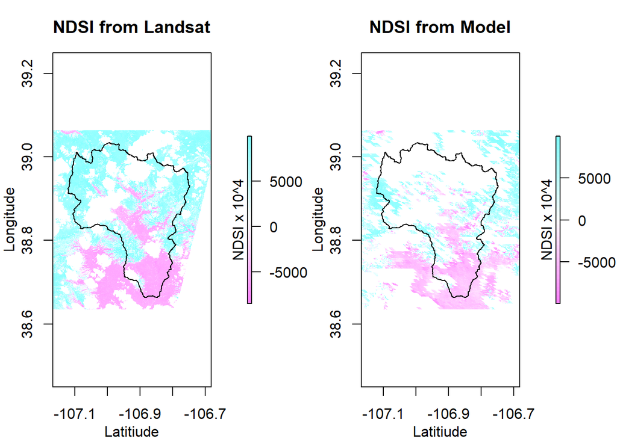

```r
## Make quick plots of the raster inputs to get an idea of the data we're working with
## Landsat 'no data' values are currently set to 0. Creating a mask to change them to -11111, which is the 'no data' value in the model output

landsat_masked<- Which(landsat_apr25 == 0, cells = TRUE)
landsat_apr25[landsat_masked] <- -11111


# Reclassify all data values less than or equal to -11111 as NA
landsat_apr25<- reclassify(landsat_apr25,cbind(-Inf, -11111, NA))
starfm_apr25<- reclassify(starfm_apr25,cbind(-Inf, -11111, NA))

# Make quick plots of the data to make sure it is formatted correctly
par(mfrow=c(1,2))
par(mar = c(3,3,3,5.5))
plot(landsat_apr25, col = rev(cm.colors(40)), main = "NDSI from Landsat")
mtext("NDSI x 10^4", side=4, line=1)
mtext("Latitiude", side=1, line=2)
mtext("Longitude", side=2, line=2)
plot(ER_proj, border = "black", add = TRUE)
plot(starfm_apr25, col = rev(cm.colors(40)), main = "NDSI from Model")
mtext("NDSI x 10^4", side=4, line=1)
mtext("Latitiude", side=1, line=2)
mtext("Longitude", side=2, line=2)
plot(ER_proj, border = "black", add = TRUE)
```

```r
## NOTE: Our NDSI values in our raster are multiplied by 10,000
```

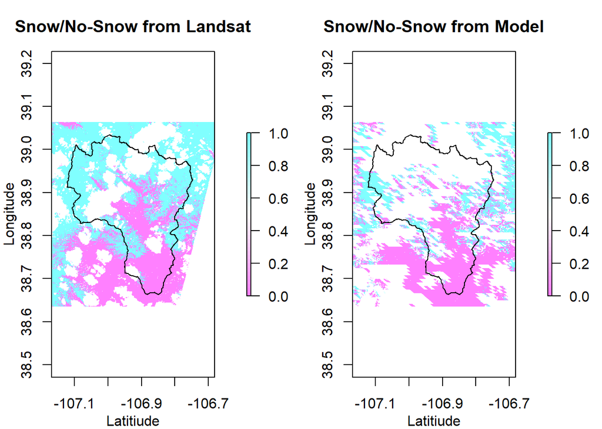

```r
## Once we know our data is displaying correctly, classify each pixel as "snow" or "no-snow" using the commonly accepted threshold of 0.4 NDSI


# Any values in our rasters of below 4000 are given a new value of zero
landsat_binary<- reclassify(landsat_apr25,cbind(-Inf, 4000, 0))
starfm_binary<- reclassify(starfm_apr25,cbind(-Inf, 4000, 0))

# Any values in our rasters of 4000 or above are given a new value of 1
landsat_binary<- reclassify(landsat_binary,cbind(4000, Inf, 1))
starfm_binary<- reclassify(starfm_binary,cbind(4000, Inf, 1))

# Plot our newly classified data to display where there is snow and where there is not
par(mfrow=c(1,2))
par(mar = c(3,3,3,5))
plot(landsat_binary,  col = rev(cm.colors(40)), main = "Snow/No-Snow from Landsat")
mtext("Latitiude", side=1, line=2)
mtext("Longitude", side=2, line=2)
plot(ER_proj, border = "black", add = TRUE)
plot(starfm_binary, col = rev(cm.colors(40)), main = "Snow/No-Snow from Model")
mtext("Latitiude", side=1, line=2)
mtext("Longitude", side=2, line=2)
plot(ER_proj, border = "black", add = TRUE)
```

```r
## In the plots shown below, "snow" is displayed in blue with a value of 1, and "no-snow" is displayed in pink with a value of 0
```

```r
## Find the fSCA for each raster


## Since "snow" pixels in our rasters have a value of 1, and all other cells have a value of zero or NA, a simple sum will give us the number of snow-covered pixels. When that value is divided by the total number of pixels in the raster (or the area of the raster), that value will be our fractional snow covered area.

# Perform the process described above on the Landsat validation data
area_L8<- landsat_apr25@nrows*landsat_apr25@ncols

L8_snow<- as.vector(landsat_binary, mode = 'numeric')
L8_snow_sum<- sum(L8_snow, na.rm = TRUE)

L8_fsca<- L8_snow_sum/area_L8  #Landsat fSCA


# Perform the process described above on the STARFM model results
area_starfm<- starfm_apr25@nrows*starfm_apr25@ncols

starfm_snow<- as.vector(starfm_binary, mode = 'numeric')
starfm_snow_sum<- sum(starfm_snow, na.rm = TRUE)

starfm_fsca<- starfm_snow_sum/area_starfm #STARFM fSCA
```

## Analysis/processing step 3 - Perform pixel-by-pixel comparison of the raster of the model results vs the raster of the Landsat data to determine how well the model does at correctly classifying snow.

Classify anything as 0.4 NDSI or greater as snow, and everything else as no-snow, for both rasters. Compare the two rasters and create a confusion matrix to quantify how well the model did at correctly classifying pixels. Calculate accuracy, precision, recall, f-score of the model.

```r
## Create a confusion matrix to evaluate the performance of the model against the Landsat data


landsat_factor<- as.factor(L8_snow)
starfm_factor<- as.factor(starfm_snow)

results<- confusionMatrix(starfm_factor,landsat_factor, positive = "1")

# Save the results in matrices that can easily be viewed for reference
overall<- as.matrix(results, what = "overall")
classes<- as.matrix(results, what = "classes")


# We want to know the values of the accuracy, precision, recall, and f-score, so we will save these values as their own variable
acc_model<- overall[[1]]
prec_model<- classes[[5]]
recall_model<- classes[[6]]
f1_model<- classes[[7]]
```

## Analysis/processing step 3 - Produce randomized rasters to evaluate model behavior against.

Create a new set of rasters with the same fraction of pixels classified as snow as the model output, but with those pixels randomly placed throughout the raster. Do this by randomly resampling the model data 100 times. Evaluate accuracy, precision, recall, and f-score metrics for each randomized raster.

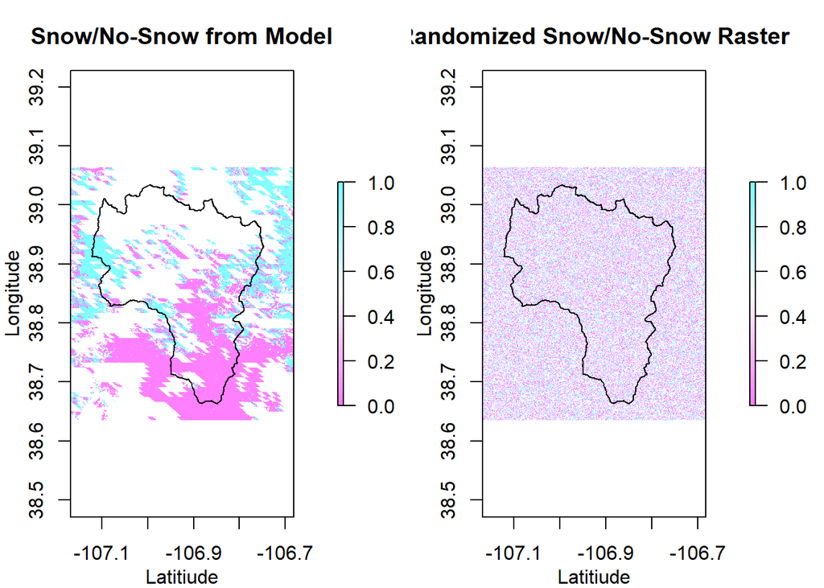

```r
## Generate our random rasters to compare our model results to

set.seed(123)

rand<- list()

## Randomize the model results by resampling them. This will preserve the same amount of 0's, 1's and NA values. Doing this in a list format for ease of computation.
n<- 100
for (i in 1:n) {
 n1<- sample(starfm_binary, replace = FALSE)
 rand[[i]] = n1
}


## Project a single random matrix as a validation test
test<- rand[[1]]
dim(test)<- c(1590, 1805)
test_sum<- sum(test, na.rm = TRUE)
r<- raster(test, crs=data_proj)
e<- extent(-107.1678, -106.6814, 38.63501, 39.06351)
extent(r)<- e
resol<- 0.0002694946
res(r)<- resol


## Can uncomment lines below to convert the list of the random samples (currently in vector format) into matrices with the correct dimensions (not necessary for analysis, but helpful for visualization or for conversion into raster format)

# rand_all<- vector("list", n)
#
# for (i in 1:length(rand)) {
#   rand_layer<- rand[[i]]
#   dim(rand_layer)<- c(1590, 1805)
#   rand_all[[i]]<- rand_layer
# }


## Can uncomment lines below to convert the matrices of the randomly sampled values into raster format and project to match the actual data. This only works with a small sample of randomized rasters (e.g. 10), otherwise file is too large.

# r_all<- vector("list", n)
#
# for(i in 1:length(rand_all)) {
#   rand_matrix<- raster(rand_all[[i]], crs=data_proj)
#   extent(rand_matrix)<- e
#   res(rand_matrix)<- resol
#   r_all[[i]]<- rand_matrix
# }


# Plot the randomized raster side-by-side with the model data to do a quick visual check on the randomized data
par(mfrow=c(1,2))
par(mar = c(3,3,3,5))
plot(starfm_binary, col = rev(cm.colors(40)), main = "Snow/No-Snow from Model")
mtext("Latitiude", side=1, line=2)
mtext("Longitude", side=2, line=2)
plot(ER_proj, border = "black", add = TRUE)
plot(r, col = rev(cm.colors(40)), main = "Randomized Snow/No-Snow Raster")
mtext("Latitiude", side=1, line=2)
mtext("Longitude", side=2, line=2)
plot(ER_proj, border = "black", add = TRUE)
```

```r
## In the same manner as the previous plots, "snow" is displayed in blue with a value of 1, and "no-snow" is displayed in pink with a value of 0
```

```r
## Run the classification with the randomized matrices and create confusion matrices for each one

# If randomized results have been converted to raster or matrix format, uncomment the lines below to convert them back to vector format for confusion matrix analysis

# r_all_vec<- vector("list", n)
#
# for (i in 1:length(r_all)) {
#  r_all_to_vec<- r_all[[i]]
#  r_all_vec[[i]]<- as.vector(r_all_to_vec, mode = 'numeric')
# }

rand_results<- vector("list", n)

for (i in 1:length(rand)) {
 vec_to_fac<- rand[[i]]
 rand_factor<- as.factor(vec_to_fac)
 rand_results_layer<- confusionMatrix(rand_factor,landsat_factor, positive = "1")
 rand_results[[i]] = rand_results_layer
}

## Store the overall statistics from each matrix in their own list variable
overall_total<- vector("list", n)

for (i in 1:length(rand_results)) {
  overall_layer<- rand_results[[i]]$overall
  overall_total[[i]] = overall_layer
}

## Store the statistics by class from each matrix in their own list variable
classes_total<- vector("list", n)

for (i in 1:length(rand_results)) {
  classes_layer<- rand_results[[i]]$byClass
  classes_total[[i]] = classes_layer
}


## Store the accuracies from the "Overall" statistics from each matrix in their own list variable
accuracy_all<- vector("list", n)

for (i in 1:length(overall_total)) {
  levels<- overall_total[[i]]
  accuracy_all[[i]] = levels[['Accuracy']]
}


## Store the precision from the "By Class" statistics from each matrix in their own list variable
precision_all<- vector("list", n)

for (i in 1:length(classes_total)) {
  levels<- classes_total[[i]]
  precision_all[[i]] = levels[['Precision']]
}


## Store the recall from the "By Class" statistics from each matrix in their own list variable
recall_all<- vector("list", n)

for (i in 1:length(classes_total)) {
  levels<- classes_total[[i]]
  recall_all[[i]] = levels[['Recall']]
}


## Store the f-score from the "By Class" statistics from each matrix in their own list variable
f1_all<- vector("list", n)

for (i in 1:length(classes_total)) {
  levels<- classes_total[[i]]
  f1_all[[i]] = levels[['F1']]
}
```